# exam 1

### Econ B2000, Statistics and Introduction to Econometrics

### Kevin R Foster, Colin Powell School, the City College of New York, CUNY

### Oct 17 2024

*The questions are worth 120 points. You have 120 minutes to do the exam, one point per minute.* *All answers should submitted electronically. Please submit all relevant computer files as a Slack message to me (perhaps just a message with GitHub link). I prefer .Rmd files **along with knit output,** md or html is fine. Please no “pages” files, save output and code as pdf or rtf if you must.* *You may refer to your books, notes, calculator, computer, etc. The exam is “open book.”* *However, you must not refer to anyone else, either in person or electronically, during the exam time. For instance, since these exam questions are newly created, posting questions or copying answers on Discord or WhatsApp groups or online homework helping sites or forums (such as Chegg, Yahoo answers or others) is a violation. Don’t upload to public GitHub site until end of exam.* *You must do all work on your own. Cheating is harshly penalized.* *Good luck. Stay cool.*

## Background

We’ll continue to use the Household Pulse Data. Now we’ll consider people who report lacking social or emotional support. Answers are on a 5-point scale from ‘always’ to ‘never’ and I will recode the three worst, ‘sometimes’,‘rarely’, and ‘never’, to be a 0/1 variable, `s_e_suport_lack`.

I’m considering this graph, which seems somewhat counterintuitive:

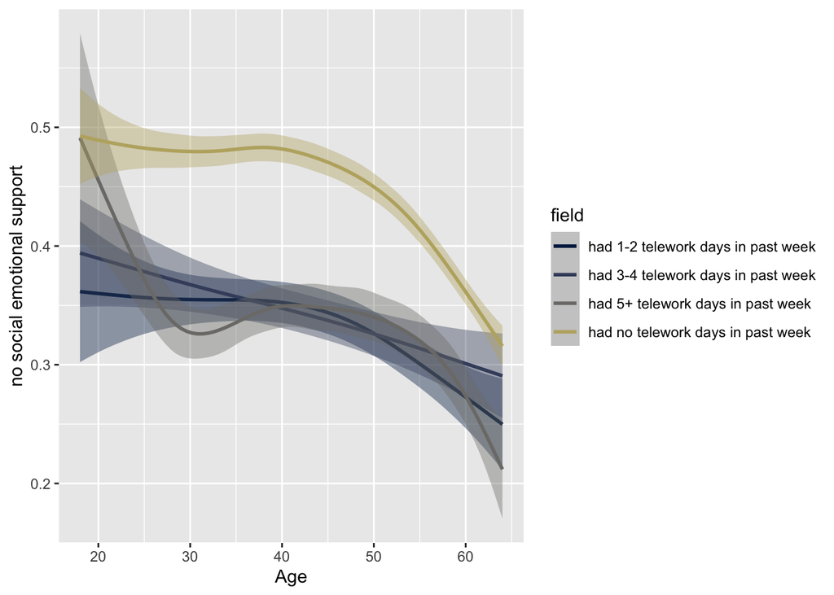

People who see their work colleagues the most, also were most likely to say they had little social or emotional support.